# Renee_data_Pandas

```python
import pandas as pd
```

Inspect the code under this section, then add a cell to:

1. Create a new dictionary, name it your firstname where firstname _fruits is your first name.
2. Add four items to the dictionary with names of your favorite fruits as keys and the respective color as values.
3. Convert the dictionary into a pandas series named firstname_f.
4. Print out the second and third items.
5. Create a sub series named firstname_f2 containing the second and third items.
6. Printout from the sub series the last item using iloc.

```python
#Create a new dictionary called renee_fruits.
renee_fruits = {}
#Add four items to the dictionary with names of your favorite fruits as keys and the respective color as values.
renee_fruits['apples'] = 'red'
renee_fruits['bananas'] = 'yellow'
renee_fruits['oranges'] = 'orange'
renee_fruits['pears'] = 'green'
print(renee_fruits)
#Convert the dictionary into a pandas series named firstname_f.
renee_f = pd.Series(renee_fruits)
renee_f
# Print out the second and third items.
print(renee_f[1:3])
# Create a sub series named firstname_f2 containing the second and third items.
renee_f2 = renee_f[1:3]
renee_f2
# Printout from the sub series the last item using iloc.
print(renee_f2.iloc[1])
```

```
{'apples': 'red', 'bananas': 'yellow', 'oranges': 'orange', 'pears': 'green'}
bananas    yellow
oranges    orange
dtype: object
orange
```

Add a cell with the following logic:

1. Create a list containing four rainfall amounts of values 10, 23,24,30 name the list firstname_amounts.
2. Using pandas create a date_range for todays date/time (you can set any time) with four time intervals.
3. Create a series that combines both the list and date range name it firstname_rainfall amounts_today.
4. Plot as bar chart.

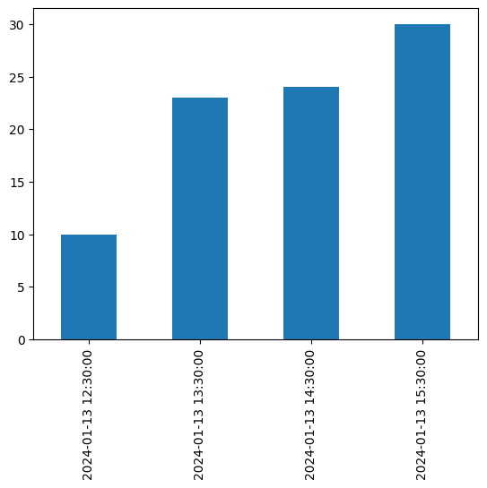

```python
# Create a list containing four  rainfall amounts  of values 10, 23,24,30 name the list firstname_amounts.
renee_amounts = [10, 23, 24, 30]
# Using pandas create a date_range for todays date/time (you can set any time) with four time intervals.
renee_dates = pd.date_range('2024-01-13 12:30pm', periods=4, freq='H')
renee_dates
# Create a series that combines both the list and date range name it firstname_rainfall amounts_today.
renee_rainfall = pd.Series(renee_amounts, renee_dates)
renee_rainfall
# Plot as bar chart.
renee_rainfall.plot(kind='bar')
```

Make a copy of the dataframe d5 and name it fristname_d5, carryout the following:

1. print out a dataframe containing all “private” columns
2. Swap the columns and rows (hint: look at transpose)

```python
# Make a copy of the dataframe d5 and name it fristname_d5, carryout the following:
# 1.	print out a dataframe containing all “private” columns
# 2.	Swap the columns and rows (hint: look at transpose)

import numpy as np
renee_d5 = pd.DataFrame(
  {
    ("public", "birthyear"):
        {("Paris","alice"):1985, ("Paris","bob"): 1984, ("London","charles"): 1992},
    ("public", "hobby"):
        {("Paris","alice"):"Biking", ("Paris","bob"): "Dancing"},
    ("private", "weight"):
        {("Paris","alice"):68, ("Paris","bob"): 83, ("London","charles"): 112},
    ("private", "children"):
        {("Paris", "alice"):np.nan, ("Paris","bob"): 3, ("London","charles"): 0}
  }
)
renee_d5["private"]

# Swap the columns and rows (hint: look at transpose)
renee_d5.T
```

|  |  | Paris alice | Paris bob | London charles |
| --- | --- | --- | --- | --- |
| public | birthyear | 1985 | 1984 | 1992 |
|  | hobby | Biking | Dancing | NaN |
| private | weight | 68 | 83 | 112 |
|  | children | NaN | 3.0 | 0.0 |

Use the query() to query the people dataframe you created earlier and retrieve everything related to alice.

```python
# Use the query() to query the people dataframe  you created earlier and retrieve everything related to alice.
alice_data = renee_d5.loc[renee_d5.index.get_level_values(1) == 'alice']
alice_data
```

|  |  | public birthyear | public hobby | private weight | private children |
| --- | --- | --- | --- | --- | --- |
| Paris | alice | 1985 | Biking | 68 | NaN |

Add a cell to create a dataframe containing grade for four students choose the name of the students and use the names as index. For columns create four columns to reflect the months April, May, June, July. Set grade items for each student for each month to be between 0 and 100. Name the dataframe fristname_grades. Carry out the following using pandas operations:

1. Print out the average for the month of April
2. Adjust all the grades by 2% (i.e. increase)
3. Printout the grades for the month of may that are higher than 50%
4. Group the failing students i.e. the students with average over four month below 50%

```python
# Add a cell to create a dataframe containing grade for four students choose the name of the students and use the names as index. For columns create four columns to reflect the months April, May, June, July. Set grade items for each student for each month to be between 0 and 100.  Name the dataframe fristname_grades.
grades = {
    'April': [95, 92, 76, 99],
    'May': [99, 99, 83, 88],
    'June': [100, 95, 90, 82],
    'July': [100, 100, 90, 82]
}
students = ['Alice', 'Bob', 'Charlie', 'Duan']
renee_grades = pd.DataFrame(grades, students)
# Print out the average for the month of April
renee_grades["April"].mean()
# Adjust all the grades by 2% (i.e. increase)
renee_grades = renee_grades + 2
# printout the grades for the month of may that are higher than 50%
renee_grades["May"][renee_grades["May"] > 50]
(renee_grades > 50).all(axis=1)
#Group the failing students i.e. the students with average over four month below 50%
renee_grades.mean(axis=1)[renee_grades.mean(axis=1) < 50]
(renee_grades < 50).all(axis=1)
```

[output not shown]